# Actividad 2 - Problema 4 - Intervalos de Confianza y Bootstrap en R

Métodos de Simulación Estadística - Maestría en Ciencia de Datos - Pontificia Universidad Javeriana Cali

- Carolina Marin Ortiz - Victor Hugo Perilla Martinez

2026-03-10

# 1 Índice

1. Índice
2. Problema 4

# 2 Problema 4

Estimación de intervalos de confianza

Una empresa dedicada a la generación de energía renovable desea evaluar el rendimiento de sus 20 generadores eléctricos portátiles, alimentados con biocombustible. Estos generadores se utilizan en proyectos remotos, donde la eficiencia energética es crucial para minimizar costos y reducir la huella ambiental. Para el estudio, se mide la eficiencia energética de cada generador, expresada en kilovatios-hora por litro de combustible (kWh/L). Los resultados son:

```r
# Muestra de eficiencia energética (kWh/L)
muestra <- c(6.12, 5.87, 5.45, 6.33, 5.71, 6.04, 5.92, 5.65, 6.18, 5.78, 5.95, 6.21, 5.63, 5.79, 6.11, 5.88, 6.02, 5.76, 5.85, 6.10)
```

El objetivo es determinar intervalos de confianza al 95% para la eficiencia media.

Realiza las siguientes actividades:

1. Normalidad:
- Elabora un histograma y una curva de densidad de la muestra. ¿Podría considerarse normal la población de origen de la muestra?
- Aplica pruebas para evaluar la normalidad. Expón claramente las hipótesis nula y alternativa. Determina el nivel de significancia adecuado. Argumenta el valor del nivel de significancia que uses.
- Comenta si los resultados sugieren la viabilidad de usar métodos paramétricos para calcular intervalos de confianza.
2. Método paramétrico:
- Si se cumplen las condiciones para su aplicación, calcula un intervalo de confianza paramétrico.
- Compara e interpreta este intervalo con los obtenidos mediante métodos no paramétricos.
3. Procedimiento bootstrap:
- Calcula 2 tipos de intervalos de confianza para la media mediante Bootstrap.
- Compara ambos intervalos: ¿Son similares o presentan diferencias significativas?

Definimos los valores a usar en la Tabla 2.1:

```r
seed <- 456
set.seed(seed) # Reproducibilidad
n <- length(muestra)
alpha <- 0.05
conf_level <- 1 - alpha
tabla_constantes <- tibble(
  Parametro = c(
    "Semilla aleatoria",
    "Tamaño de muestra",
    "Nivel de significancia (alpha)",
    "Nivel de confiabilidad"
  ),
  Valor = c(
    seed,
    n,
    alpha,
    conf_level
  )
)
knitr::kable(
  tabla_constantes,
  digits = 4,
  caption = "Valores a tener en cuenta para este problema.",
  format = "html"
) %>%
  kable_styling(
    bootstrap_options = c("bordered", "striped", "hover"),
    full_width = FALSE,
    font_size = 11
  )
```

Table 2.1: Valores a tener en cuenta para este problema.

| Parametro | Valor |
| --- | --- |
| Semilla aleatoria | 456.00 |
| Tamaño de muestra | 20.00 |
| Nivel de significancia (alpha) | 0.05 |
| Nivel de confiabilidad | 0.95 |

## 2.1 4.a. Normalidad

Para inciiar validaremos la distribución de la muestra.

```r
data_temp <- data.frame(muestra = muestra)

lista_resultados <- list()
vars_graph <- c("muestra")

for(v in vars_graph) {

  vec <- as.numeric(data_temp[[v]])

  n_total <- length(vec)
  n_na <- sum(is.na(vec))
  pct_na <- (n_na / n_total) * 100

  vec_clean <- na.omit(vec)
  n_subdataset <- length(vec_clean)

  # --- Outliers (1.5 IQR) ---
  q1 <- quantile(vec_clean, 0.25)
  q3 <- quantile(vec_clean, 0.75)
  iqr_val <- q3 - q1

  lim_inf <- q1 - 1.5 * iqr_val
  lim_sup <- q3 + 1.5 * iqr_val

  outliers <- vec_clean[vec_clean < lim_inf | vec_clean > lim_sup]
  n_outliers <- length(outliers)

  pct_outliers <- (n_outliers / n_subdataset) * 100

  tabla <- descr(
    vec_clean,
    stats = c("n.valid","min","q1","med","q3","max","mean","sd","cv"),
    transpose = TRUE
  ) %>%
    tb() %>%
    rename(Estadistico = 1) %>%
    mutate(
      Variable = v,
      Outliers_N = n_outliers,
      Pct_Outliers = pct_outliers,
      Datos_NA = n_na,
      Pct_Datos_NA = pct_na
    )

  lista_resultados[[v]] <- tabla
}

tabla_maestra <- bind_rows(lista_resultados)

knitr::kable(
  tabla_maestra,
  digits = 2,
  caption = "Análisis descriptivo y outliers (Regla 1.5·IQR) de la muestra",
  format = "html"
) %>%
  kable_styling(
    bootstrap_options = c("bordered", "striped", "hover"),
    full_width = FALSE,
    font_size = 11
  )
```

Table 2.2: Análisis descriptivo y outliers (Regla 1.5·IQR) de la muestra

| Estadistico | n.valid | min | q1 | med | q3 | max | mean | sd | cv | Variable | Outliers_N | Pct_Outliers | Datos_NA | Pct_Datos_NA |
| --- | --- | --- | --- | --- | --- | --- | --- | --- | --- | --- | --- | --- | --- | --- |
| vec_clean | 20 | 5.45 | 5.77 | 5.9 | 6.11 | 6.33 | 5.92 | 0.22 | 0.04 | muestra | 0 | 0 | 0 | 0 |

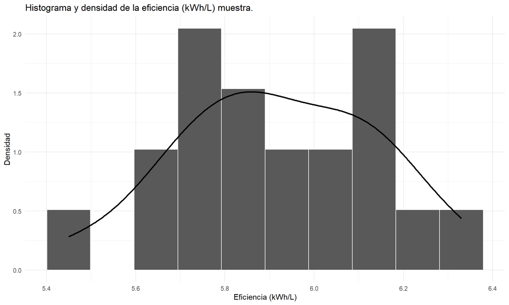

Figure 2.1: Histograma y densidad de la eficiencia (kWh/L) muestra.

```r
df <- tibble(x = muestra)

ggplot(df, aes(x = x)) +
  geom_histogram(aes(y = after_stat(density)), bins = 10, color = "white") +
  geom_density(linewidth = 1) +
  labs(
    title = "Histograma y densidad de la eficiencia (kWh/L) muestra.",
    x = "Eficiencia (kWh/L)",
    y = "Densidad"
  ) +
  theme_minimal()
```

De la Tabla 2.2 vemos `Mediana - Q1 = 0.13` y que `Q3 - Mediana = 0.21`, por lo cual hay ligera asimetría derecha, pero nada extremo. No vemos outliers en la muestra. La media 5.92 y la mediana 5.9, aproximadamente iguales. La dispersión es muy baja, inclusive el coeficiente de variación de 0.04 muestra que es muy estable la media. La muestra presenta características compatibles con una distribución aproximadamente normal y sugiere que los datos son consistentes y homogéneos.En la figura 2.1 vemos un histograma el cual forma aproximadamente simétrica, con una curva densidad en forma de campana, que para pocas muestras puede mostrar una form similar a la distribución normal.

Prueba de Shapiro–Wilk: Es la prueba más potente para muestras pequeñas (n < 50). En nuestro caso n = 20 por lo que el resultado de esta prueba es fiable.

- Hipótesis H0 (nula): los datos provienen de una Distribución Normal
- Hipótesis H1 (alternativa): los datos no provienen de una distribución normal

```r
shapiro <- shapiro.test(muestra)
cat("Test de normalidad Shapiro-Wilk\n")
```

```
## Test de normalidad Shapiro-Wilk
```

```r
if(shapiro$p.value > alpha){

  cat(paste0(
    "Conclusión: No se rechaza H0 (p-value = ",
    round(shapiro$p.value,4), " y alpha de ",alpha,
    ").\n"
  ))

  cat("Los datos son compatibles con una distribución normal.")

} else {

  cat(paste0(
    "Conclusión: Se rechaza H0 (p-value = ",
    round(shapiro$p.value,4), " y alpha de ",alpha,
    ").\n"
  ))

  cat("Los datos no siguen una distribución normal.")
}
```

```
## Conclusión: No se rechaza H0 (p-value = 0.9955 y alpha de 0.05).
## Los datos son compatibles con una distribución normal.
```

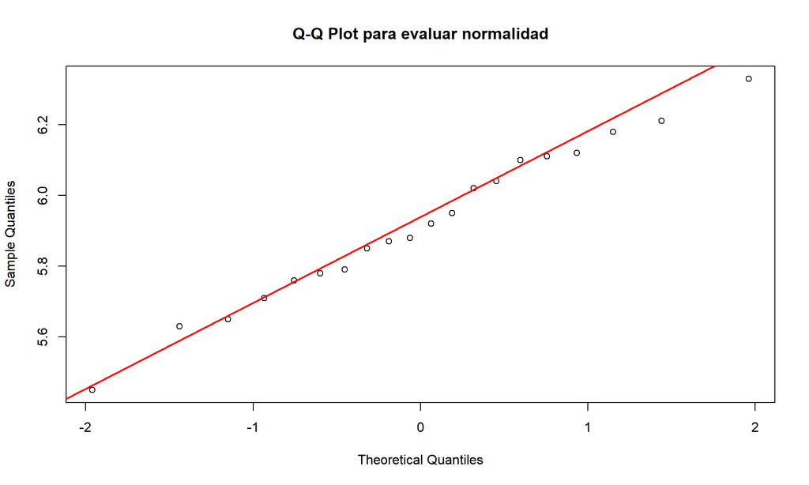

Figure 2.2: Q-Q Plot para evaluar normalidad

```r
qqnorm(muestra,
       main = "Q-Q Plot para evaluar normalidad")

qqline(muestra,
       col = "red",
       lwd = 2)
```

Se aplicó la prueba de Shapiro-Wilk con un nivel de significancia de α = 0.05, los resultados se observa que cumple la hipótesis nula: los datos provienen de una distribución normal. Esto dado que el valor p obtenido fue mayor que 0.05, por lo que no se rechaza la hipótesis de normalidad.

## 2.2 4.b. Método paramétrico para intervalo de confianza

Cuando la varianza poblacional es desconocida y la muestra es pequeña, se usa la distribución t.

$$IC = \bar{x} \pm t_{\alpha/2,n-1}\frac{s}{\sqrt{n}}$$

```r
cat("Resultado de intervalo de confiaza para distribución t")
```

```
## Resultado de intervalo de confiaza para distribución t
```

```r
ic_parametrico <- t.test(muestra, conf.level = conf_level)
ic_parametrico
```

```
##
##  One Sample t-test
##
## data:  muestra
## t = 118.56, df = 19, p-value < 2.2e-16
## alternative hypothesis: true mean is not equal to 0
## 95 percent confidence interval:
##  5.813038 6.021962
## sample estimates:
## mean of x
##    5.9175
```

Por lo tanto, el intervalo de confianza para la media poblacional es: `IC95%=(5.813038,6.021962)`, lo que indica que con un 95% de confianza, la media verdadera de la población se encuentra entre: `5.813 ≤𝜇≤ 6.022` usando el Paramétrico t.

## 2.3 4.c. Procedimiento bootstrap para calculo de intervalod e confianza

Se recurre a técnicas no paramétricas para estimar el intervalo de confianza, como el método bootstrap, el bootstrap permite estimar la distribución del estimador mediante remuestreo con reemplazo. El método **bootstrap** consiste en generar múltiples muestras a partir de la muestra original mediante **remuestreo con reemplazo**. Sea una muestra original de tamaño:

$$n = 20$$

Cada muestra bootstrap también tiene tamaño $n$, y cada posición de la muestra puede tomar cualquiera de los valores de la muestra original. Por lo tanto, el número total de posibles muestras bootstrap está dado por:

$$n^n$$

En este caso:

$$20^{20}$$

Calculando este valor:

$$20^{20} = 1.048576e+26$$

Debido a que este número es muy grande, **no es posible generar todas las combinaciones posibles**. Por esta razón, el bootstrap utiliza una **aproximación por simulación**, en este caso usaremos un `B = 10000` muestras de bootstrap que permitirá tener mucho menor error y un alpha de 0.05.

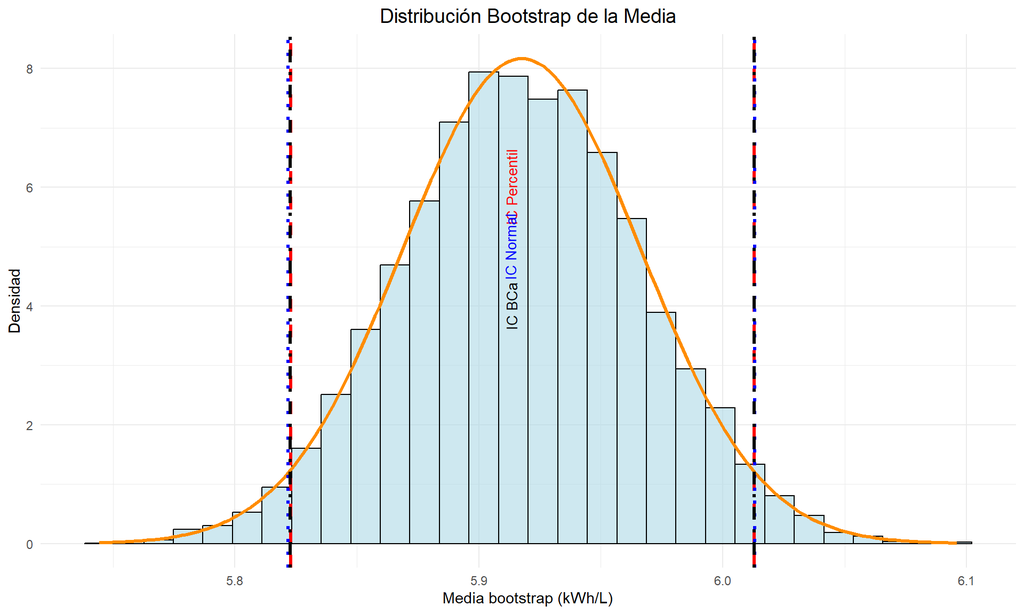

```r
#función para sacar la media

B = 10000

boot_function <- function(data, indices) {
  mean(data[indices])
}

boot_results <- boot(data = muestra, statistic = boot_function, R = B)

# Distribución bootstrap de la media
bootstrap_media <- as.vector(boot_results$t)

# Media y desviación estándar bootstrap
mean_bootstrap <- mean(bootstrap_media)
sd_bootstrap <- sd(bootstrap_media)

# Intervalos de confianza
IC.p   <- boot.ci(boot_results, type = "perc")$percent[4:5]
IC.N   <- boot.ci(boot_results, type = "norm")$normal[2:3]
IC.BCa <- boot.ci(boot_results, type = "bca")$bca[4:5]

# Dataframe para la gráfica
df <- data.frame(bootstrap_media = bootstrap_media)

# Curva normal ajustada
x_vals <- seq(min(bootstrap_media), max(bootstrap_media), length.out = 200)
normal_curve <- data.frame(
  x = x_vals,
  y = dnorm(x_vals, mean = mean_bootstrap, sd = sd_bootstrap)
)

# Gráfica
plot.boot.c <- ggplot(df, aes(x = bootstrap_media)) +
  geom_histogram(aes(y = after_stat(density)),
                 bins = 30,
                 fill = "lightblue",
                 color = "black",
                 alpha = 0.6) +
  geom_line(data = normal_curve,
            aes(x = x, y = y),
            color = "darkorange",
            linewidth = 1.2) +
  geom_vline(xintercept = IC.p,
             color = "red",
             linetype = "dashed",
             linewidth = 1.1) +
  geom_vline(xintercept = IC.N,
             color = "blue",
             linetype = "dotted",
             linewidth = 1.1) +
  geom_vline(xintercept = IC.BCa,
             color = "black",
             linetype = "dotdash",
             linewidth = 1.1) +
  labs(
    title = "Distribución Bootstrap de la Media",
    x = "Media bootstrap (kWh/L)",
    y = "Densidad"
  ) +
  theme_minimal() +
  theme(plot.title = element_text(hjust = 0.5, size = 14)) +
  annotate("text", x = mean(IC.p), y = 6,
           label = "IC Percentil", color = "red", angle = 90, vjust = -0.5, size = 3.5) +
  annotate("text", x = mean(IC.N), y = 5,
           label = "IC Normal", color = "blue", angle = 90, vjust = -0.5, size = 3.5) +
  annotate("text", x = mean(IC.BCa), y = 4,
           label = "IC BCa", color = "black", angle = 90, vjust = -0.5, size = 3.5)

print(plot.boot.c)
```

El al figura 2.3 podemos ver una distribución normal de la media como lo indica el teorema del limite central, vemos los diferentes marcadores para intervalos de confianza.

```r
comparacion <- tibble(
  Metodo = c("Paramétrico t",
             "Bootstrap Percentil",
             "Bootstrap Normal",
             "Bootstrap BCa"),
  IC_INFERIOR = c(ic_parametrico$conf.int[1],
                  IC.p[1],
                  IC.N[1],
                  IC.BCa[1]),
  IC_SUPERIOR = c(ic_parametrico$conf.int[2],
                  IC.p[2],
                  IC.N[2],
                  IC.BCa[2])
)


knitr::kable(
  comparacion,
  digits = 4,
  caption = "Comparativo de intervalos de confianza",
  format = "html"
) %>%
  kable_styling(
    bootstrap_options = c("bordered", "striped", "hover"),
    full_width = FALSE,
    font_size = 11
  )
```

Table 2.3: Comparativo de intervalos de confianza

| Metodo | IC_INFERIOR | IC_SUPERIOR |
| --- | --- | --- |
| Paramétrico t | 5.8130 | 6.0220 |
| Bootstrap Percentil | 5.8230 | 6.0130 |
| Bootstrap Normal | 5.8217 | 6.0132 |
| Bootstrap BCa | 5.8227 | 6.0130 |

Para evaluar si la distribución de las varianzas bootstrap se aproxima a una distribución normal, se pueden calcular estadísticas descriptivas como la asimetría y la curtosis, así como aplicar distintos tests de normalidad. No obstante, cuando el número de remuestreos es grande (por ejemplo 𝐵= 10000), los tests de normalidad tienden a ser muy sensibles y pueden rechazar la hipótesis de normalidad incluso ante desviaciones pequeñas.

Por esta razón, además del valor-p de los tests, es recomendable analizar medidas de forma de la distribución como la asimetría y la curtosis, así como inspeccionar gráficamente la distribución bootstrap.

Si la distribución bootstrap es aproximadamente simétrica y cercana a una normal, el intervalo bootstrap normal puede ser una aproximación adecuada. En cambio, si se observa asimetría o los tests de normalidad rechazan la hipótesis nula, es preferible utilizar intervalos bootstrap Percentil o BCa, siendo este último generalmente más robusto porque corrige el sesgo y la asimetría de la distribución.

Dado el tamaño grande de B, puede adoptarse un nivel de significancia más estricto, como alpha = 0.01, para reducir la probabilidad de rechazar la normalidad por desviaciones menores.

```r
# options(repos = c(CRAN = "https://cloud.r-project.org"))

# Función para calcular la estadística de interés (en este caso, la media)
boot_function <- function(data, indices) {
  return(var(data[indices]))
}

# Generar muestras bootstrap usando la librería boot
boot_results <- boot(data = muestra, statistic = boot_function, R = B)

# Obtener la distribución de medias bootstrap
bootstrap_var <- boot_results$t

# Test de Anderson-Darling
ad_test <- ad.test(bootstrap_var)

# Test de Cramer-von Mises
cvm_test <- cvm.test(bootstrap_var)

# Test de Lilliefors (Kolmogorov-Smirnov modificado)
lillie_test <- lillie.test(bootstrap_var)

# Test de D'Agostino-Pearson (manual: usa asimetría y curtosis)
skewness_value <- skewness(bootstrap_var)
kurtosis_value <- kurtosis(bootstrap_var)

# Mostrar resultados
#list(
#  Anderson_Darling_p_value = ad_test$p.value,
#  Cramer_von_Mises_p_value = cvm_test$p.value,
#  Lilliefors_p_value = lillie_test$p.value,
#  DAgostino_Pearson_Skewness = skewness_value,
#  DAgostino_Pearson_Kurtosis = kurtosis_value
#)

tabla_tests <- tibble(
  Test = c(
    "Anderson-Darling p-valor",
    "Cramer-von Mises p-valor",
    "Lilliefors p-valor",
    "D’Agostino-Pearson Skewness",
    "D’Agostino-Pearson Kurtosis"
  ),

  Resultado = c(
    ad_test$p.value,
    cvm_test$p.value,
    lillie_test$p.value,
    skewness_value,
    kurtosis_value
  ),

  Interpretacion = c(
    ifelse(ad_test$p.value < 0.01,
           "Se rechaza la normalidad, pues valor-p < 0.01.",
           "No se rechaza la normalidad."),

    ifelse(cvm_test$p.value < 0.01,
           "Se rechaza la normalidad, pues valor-p < 0.01.",
           "No se rechaza la normalidad."),

    ifelse(lillie_test$p.value < 0.01,
           "Se rechaza la normalidad, pues valor-p < 0.01.",
           "No se rechaza la normalidad."),

    ifelse(abs(skewness_value) < 0.5,
           "Indica que la distribución es casi simétrica.",
           "Indica presencia de asimetría."),

    ifelse(abs(kurtosis_value - 3) < 0.5,
           "Es cercano a 3, lo que sugiere colas similares a la normal.",
           "Las colas difieren de una distribución normal.")
  )
)

knitr::kable(
  tabla_tests,
  digits = 6,
  caption = "Resultados de tests de normalidad y medidas de simetría",
  format = "html"
) %>%
  kable_styling(
    bootstrap_options = c("bordered", "striped", "hover"),
    full_width = FALSE,
    font_size = 11
  )
```

Table 2.4: Resultados de tests de normalidad y medidas de simetría

| Test | Resultado | Interpretacion |
| --- | --- | --- |
| Anderson-Darling p-valor | 0.000000 | Se rechaza la normalidad, pues valor-p < 0.01. |
| Cramer-von Mises p-valor | 0.000000 | Se rechaza la normalidad, pues valor-p < 0.01. |
| Lilliefors p-valor | 0.000000 | Se rechaza la normalidad, pues valor-p < 0.01. |
| D’Agostino-Pearson Skewness | 0.382934 | Indica que la distribución es casi simétrica. |
| D’Agostino-Pearson Kurtosis | 3.105988 | Es cercano a 3, lo que sugiere colas similares a la normal. |

En la tabla 2.4, los tres tests de normalidad (Anderson-Darling, Cramer-von Mises y Lilliefors) tienen valor−p menores a 0.01, lo que significa que se rechaza la hipótesis nula de normalidad. Por otro lado los valores de asimetría y curtosis están dentro del rango esperado para una distribución normal, sugieren que la distribución de las varianzas bootstrap es aproximadamente normal.

En conclusion, los resultados de los intervalos bootstrap (Percentil, Normal y BCa) son muy similares al intervalo paramétrico basado en la distribución t. Dado que las pruebas de normalidad paramétricas no rechazan la hipótesis de normalidad y el gráfico Q-Q respalda esta suposición, el intervalo paramétrico es apropiado para este problema.